# Philadelphia Homeless Shelter Location

### Logistic Regression for Homeless Dataset

#### CPLN 680 (Capstone) Regression Model 1

##### Pennsylvania University

This is an R Markdown document. I use thhis R Markdown as the way to display the statistic calculation that I applied for the Homeless shelters in Philadelphia. The main study topic of my Capstone (CPLN 680) is about the group of Homeless in the City of Philadelphia.Although each region has their own special features that can influence the region’s homelessness, the distribution of homeless people can be well predicted by seeing the location of homeless shelters, particularly in the NorthEast region of United States - the harsh winter drives homeless population gathering near the homeless shelter. Through using the location of homeless shelters in Philadelphia as the study’s Independent variable, using 10 geographical factors as Dependent variables, I trained and tested the homeless dataset with the logistic regression model, trying to define the relationship between the dependent varaibles and the independent variable - are those dependent factors statistical significant? what other data information could the logistic regression tell us?

#### Loading the package

```r
library(caret)
#install.packages("glmnet")
library(glmnet)
library(Metrics)
library(ggplot2)
library(sf)
library(dplyr)
library(tidyverse)
library(ggmap)
```

First we want to check the initial data layer * Layer One : Philadelphia Boundary Shapefile

```r
philly <- st_read("C:/Users/xiaot/Desktop/AdvancedGISTopic/phillymaps/boudary.shp")
```

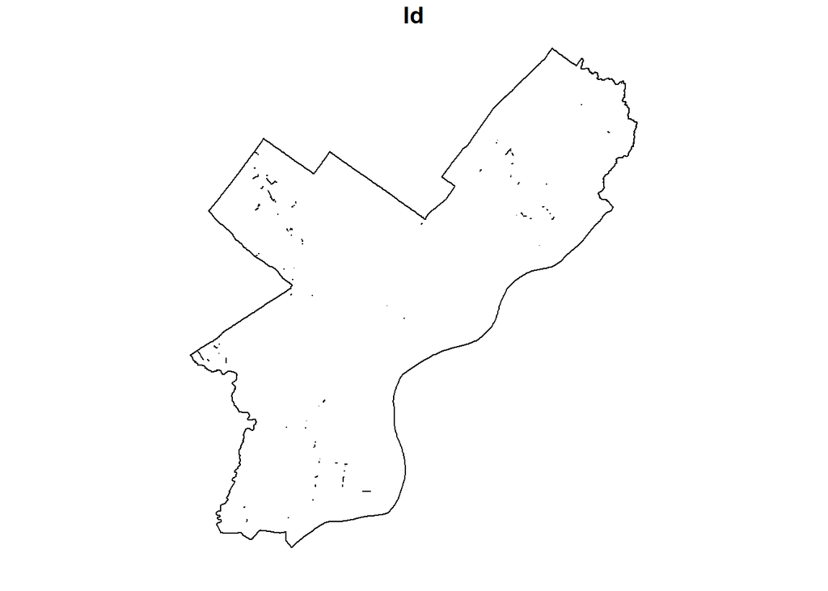

```r
plot(philly, col="#FFFFFF")
```

#### Secondly, we want to check the Homeless data layer

```r
segments <- st_read("C:/Users/xiaot/Desktop/AdvancedGISTopic/phillymaps/try_04261.shp")
```

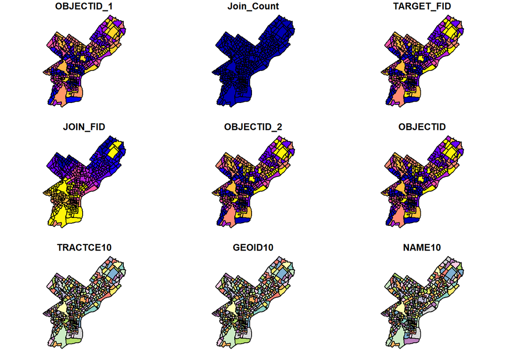

```r
plot(segments)
```

```r
# Rename the Homeless layer's col name
names(segments)[names(segments) == 'MEAN_12_13'] <- 'dist_ahcol'
names(segments)[names(segments) == 'MAPNAME'] <- 'mapname'
names(segments)[names(segments) == 'MEAN_12'] <- 'road_dens'
names(segments)[names(segments) == 'MEAN'] <- 'hospital_dens'
names(segments)[names(segments) == 'zonal_dis_'] <- 'college_dense'
```

Selecting the varaibles that we need from the initial data layer, changing the “shelters” and “affordable housing” to factors - only containing 0 (no feature in this pixel) and 1 (has feature in this pixel)

Checking the content of the “newdata1”

```
## 'data.frame':    1201 obs. of  14 variables:
##  $ road_dens    : num  1.49 1.49 1.49 1.22 1.22 ...
##  $ hospital_dens: num  1634 1634 1634 1573 1573 ...
##  $ college_dense: num  820 820 820 1077 1077 ...
##  $ danger_pro   : num  29 29 29 11 11 11 8 8 8 8 ...
##  $ crime_dens   : num  64831 64831 64831 58775 58775 ...
##  $ income1      : num  24402 24402 24402 28534 28534 ...
##  $ medrent1     : num  893 893 893 865 865 865 576 576 576 576 ...
##  $ population   : num  4311 4311 4311 2118 2118 ...
##  $ dist_alcho   : num  0.00176 0.00176 0.00176 0.00152 0.00152 ...
##  $ dis_hydro    : num  920 920 920 473 473 ...
##  $ shelters     : Factor w/ 2 levels "0","1": 1 1 1 1 1 1 1 1 1 1 ...
##  $ affordable   : Factor w/ 2 levels "0","1": 1 1 1 1 1 1 1 1 1 1 ...
##  $ mapname      : Factor w/ 158 levels "Academy Gardens",..: 22 60 98 9 119 40 9 119 90 40 ...
##  $ geometry     :sfc_MULTIPOLYGON of length 1201; first list element: List of 1
##   ..$ :List of 1
##   .. ..$ : num [1:40, 1:2] 814193 814141 814083 814023 813973 ...
##   ..- attr(*, "class")= chr  "XY" "MULTIPOLYGON" "sfg"
##  - attr(*, "sf_column")= chr "geometry"
##  - attr(*, "agr")= Factor w/ 3 levels "constant","aggregate",..: NA NA NA NA NA NA NA NA NA NA ...
##   ..- attr(*, "names")= chr  "road_dens" "hospital_dens" "college_dense" "danger_pro" ...
```

In this step, we want to set the training dataset (80%) and the testing dataset (20%).We will retrain the logistic regression model on a random sample that being generated from the training dataset instead of the entire dataset.

When running the model, we want to de-select the geometry from the dataset, and running all other factors with the regression model.

```
##          llh      llhNull           G2     McFadden         r2ML
## -217.8591531 -337.8804895  240.0426728    0.3552183    0.2208289
##         r2CU
##    0.4376039
```

I mainly used the value of McFadden as the indicator to indicate the predicting result’s quality. The McFadden number in the glm (generalized linear model) works like the r square in the OLS regression, and the range of good fit is 0,2 - 0.4. The McFadden value generalized using the Homeless dataset equals to 0.355, which is a good fit value, indicating the fact that the independent variable - “the homeless shelter” has spatial relationship with dependent variables.

```
##    Results        Probs
## 4        0 7.621775e-09
## 14       0 1.437309e-09
## 25       0 3.367212e-01
## 35       0 1.586393e-09
## 38       0 1.448734e-09
## 57       0 1.925584e-01
```

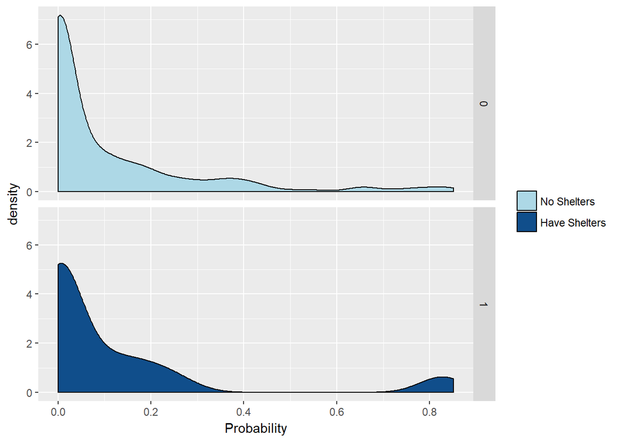

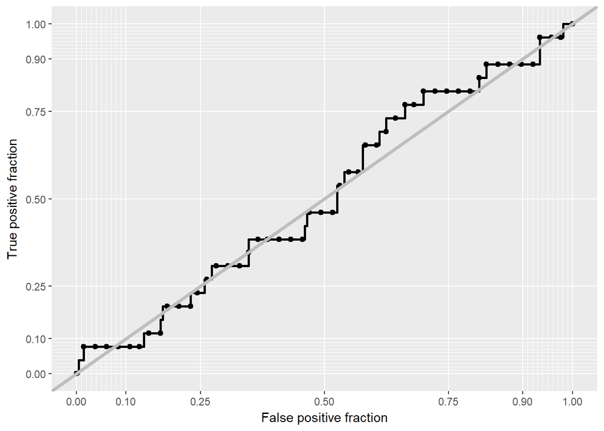

For the last graph, I want to use “auc” to check what percentage of graph is under the curve line, the percentage of “false positive”

```r
auc(newCTestProbs$Results, newCTestProbs$Probs)
```

```
## Area under the curve: 0.4888
```

Generally speaking, the percentage under the curve should reach to 60% to reach a high accuracy. Due to the small sample size I used (approximatly 300 census tracts area), the precision is lower than using the large sample size.